# Elasticity Documentation

Lila Sahar and Juan Malaver

10/18/2021

## Introduction

### What is Elasticity?

Elasticity is the percentage change in consumer demand in response to price changes.

### Why is Elasticity important?

Elasticity helps businesses price their products and services. As it quantifies the relationship between sales and prices, it will help a company predict how the market will react when you change the price of a service or product.

## Business Problem

We will use *price elasticity of demand* ($\beta$) to understand how changes in `price` impact changes in `sales`.

$$\text{log}(\texttt{sales})=\alpha+\beta\text{log}(\texttt{price})+\epsilon$$

## Cereal Data

Our data table:

| sales | price | description |
| --- | --- | --- |
| 16 | 2.9 | CINNAMON TOAST CRUNC |
| 16 | 2.9 | CINNAMON TOAST CRUNC |
| 8 | 2.9 | CINNAMON TOAST CRUNC |
| 8 | 2.9 | CINNAMON TOAST CRUNC |
| 8 | 2.9 | CINNAMON TOAST CRUNC |
| 7 | 2.9 | CINNAMON TOAST CRUNC |

## Distribution of Sales and Price by Brand

This shows that the data follows a bell shaped distribution (relatively normal) after we transform the data with logarithms.

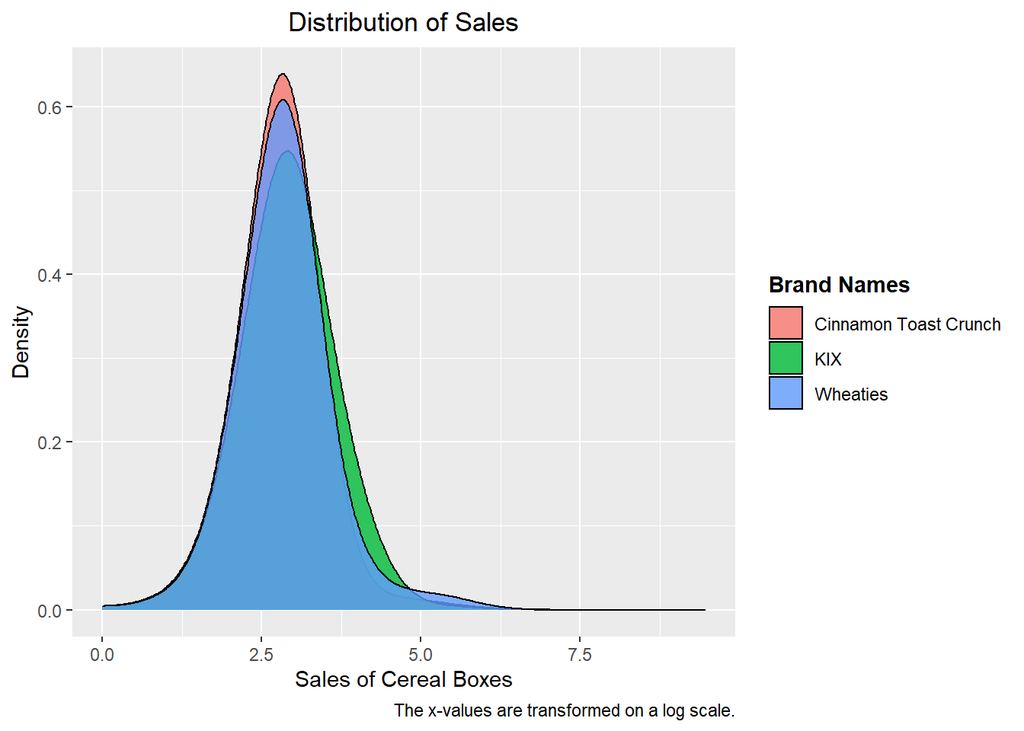

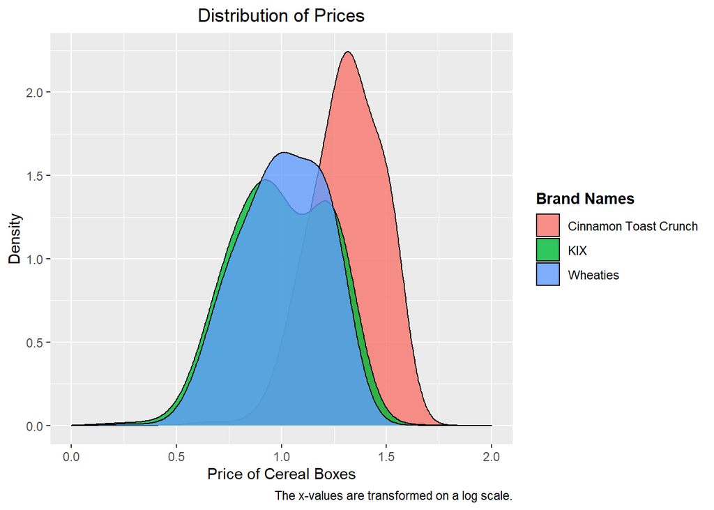

## Prices and Sales by Brand

The y and x variables have a somewhat linear relationship after transforming it with logarithms.

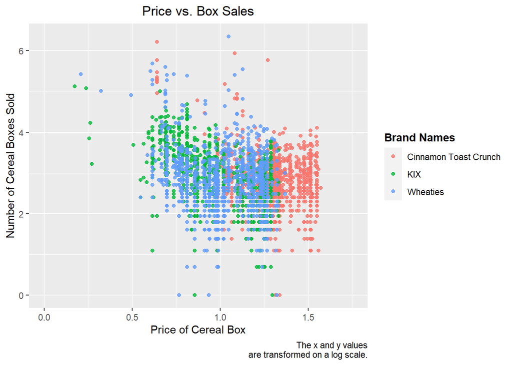

## Interpreting Price Elasticity

**Inelastic**: The percentage change in quantity demanded is proportionally lower than percentage change in price.

**Elastic**: The percentage change in quantity demanded is proportionally higher than percentage change in price.

`sales` increase by $\beta\%$ for every $1\%$ increase in `price`.

$$\frac{dy}{dx}=\frac{\beta}{x}e^{\alpha+\beta\text{log}(x)+\epsilon}\Rightarrow\beta=\frac{dy/y}{dx/x}$$

`sales` and `price` must be strictly non-negative and we assume their conditional *distribution* follows a Normal distribution.

$$y|\boldsymbol{x}\sim \mathcal{N}(\boldsymbol{x'\beta},\sigma^2)$$

### Interpretting the results

If the good is inelastic, then $\left|\beta\right|$ < 1. This means that if the price were to increase, the revenue for the firm is likely to increase.

If the good is elastic, then $\left|\beta\right|$ > 1. This means that if the price were to increase, the revenue for the firm is likely to decrease.

If the good is unitary elastic, then $\left|\beta\right|$ = 1. This means the regardless of the price, the revenue is likely to stay relatively the same.

| term | estimate | std.error | statistic | p.value |
| --- | --- | --- | --- | --- |
| (Intercept) | 4.3028139 | 0.0118187 | 364.06698 | 0 |
| log(price) | -1.1653472 | 0.0087647 | -132.95911 | 0 |
| descriptionKIX | -0.2308772 | 0.0049227 | -46.90006 | 0 |
| descriptionWHEATIES | -0.2924981 | 0.0047581 | -61.47417 | 0 |

## What does this mean regarding competitors?

**Income Elasticity** - The percentage change in quantity demanded is proportional to the percentage change in income of the consumer.

If the income elasticity is negative, the good is inferior. This means that an increase in income will lead to a fall in the quantity demanded. For example, store-brand grocery products.

If the income elasticity is positive, the good is normal. This means that an increase in income will lead to a rise in quantity demanded. For example, clothing.

If the income elasticity is zero, the good does not change the quantity demanded of the good.

**Cross Elasticity** - The percentage change in quantity demanded of good A is proportional to the percentage change in quantity demanded of good B.

If cross elasticity is positive, the goods are substitutes. This means that the demand for good A will increase as the price of good B increases. For example, iPhone and Android Phones.

If cross elasticity is negative, the goods are complements. This means that the demand for good A will increase as the price of good B decreases. For example, cereal and milk.

If the cross elasticity is zero, the demand for good A is not effected by the price change in good B.

**Price Elasticity of Supply** - The percentage change in quantity supplied is proportional to the percentage change in price.

If absolute value of price elasticity of supply = 1, the good is unit elastic. The percentage change in quantity supplied is proportionally equal to percentage change in price.